# Generate figures in Platform Effect Demonstration

Ningshan Li

2024/07/14

# 1 Summary

This R Notebook generates figures for **Platform Effect Demonstration**.

1. **Inputs**:
   - [`all_results.rds`](https://github.com/az7jh2/SDePER_Analysis/blob/main/PlatEffDemo/PlatEffDemo_all_results.rds): cell type deconvolution results.
   - [`PlatEffDemo_ref_scRNA_SDePER_WITH_CVAE_diagnosis.tar`](https://github.com/az7jh2/SDePER_Analysis/blob/main/PlatEffDemo/PlatEffDemo_ref_scRNA_SDePER_WITH_CVAE_diagnosis.tar): Compressed file including all diagnostic plots from running SDePER in this simulation.
   - [`STARmap_cell_celltype.csv`](https://github.com/az7jh2/SDePER_Analysis/blob/main/Simulation/Run_SDePER_on_simulation_data/Scenario_1/ref_spatial/STARmap_cell_celltype.csv): cell type annotation of all 2,002 STARmap cells.
   - [`ref_scRNA_cell_celltype.csv`](https://github.com/az7jh2/SDePER_Analysis/blob/main/Simulation/Run_SDePER_on_simulation_data/Scenario_1/ref_scRNA_seq/ref_scRNA_cell_celltype.csv): cell type annotation of cells in external scRNA-seq reference data.
2. **Outputs**:
   - Figure. UMAP of STARmap and scRNA-seq reference cells before and after CVAE transforming, as well as the UMAP of latent embeddings of those cells
   - Figure. Boxplot of performance on simulated data

# 2 Version

```r
version[['version.string']]
```

```
[1] "R version 4.2.2 Patched (2022-11-10 r83330)"
```

```r
print(sprintf('Package %s version: %s', 'ggplot2', packageVersion('ggplot2')))
```

```
[1] "Package ggplot2 version: 3.4.2"
```

```r
print(sprintf('Package %s version: %s', 'ggpubr', packageVersion('ggpubr')))
```

```
[1] "Package ggpubr version: 0.6.0"
```

```r
print(sprintf('Package %s version: %s', 'philentropy', packageVersion('philentropy'))) # JSD function
```

```
[1] "Package philentropy version: 0.7.0"
```

# 3 Read relevant files

## 3.1 Read STARmap cell annotation

```r
file_name = file.path(home.dir, 'STARmap_cell_celltype.csv')
starmap_cell_anno = read.csv(file_name, row.names = 1, check.names = F, stringsAsFactors = F)
print(sprintf('load data from %s', file_name))
```

```
[1] "load data from /home/hill103/Documents/Spatial/PlatEffDemo/STARmap_cell_celltype.csv"
```

```r
print(sprintf('total %d cells', nrow(starmap_cell_anno)))
```

```
[1] "total 2002 cells"
```

```r
table(starmap_cell_anno$celltype)
```

```
Astro eL2/3   eL4   eL5   eL6  Endo Micro Oligo PVALB   Smc   SST   VIP
  259   292   327   110   368   134    69   278    61    42    33    29
```

generate the truth cell type proportion.

```r
celltype_order = c("Astro", "eL2/3", "eL4", "eL5", "eL6", "Endo", "Micro", "Oligo", "PVALB", "Smc", "SST", "VIP")
truth = data.frame(matrix(0, nrow=nrow(starmap_cell_anno), ncol=length(celltype_order)))
colnames(truth) = celltype_order
row.names(truth) = row.names(starmap_cell_anno)

for (i in 1:nrow(starmap_cell_anno)) {
  truth[i, starmap_cell_anno[i, 'celltype']] = 1
}
```

## 3.2 Read cell type annotation of external reference

```r
file_name = file.path(home.dir, 'ref_scRNA_cell_celltype.csv')
ref_cell_anno = read.csv(file_name, row.names = 1, check.names = F, stringsAsFactors = F)
print(sprintf('load data from %s', file_name))
```

```
[1] "load data from /home/hill103/Documents/Spatial/PlatEffDemo/ref_scRNA_cell_celltype.csv"
```

```r
print(sprintf('total %d cells', nrow(ref_cell_anno)))
```

```
[1] "total 11835 cells"
```

```r
table(ref_cell_anno$celltype)
```

```
Astro eL2/3   eL4   eL5   eL6  Endo Micro Oligo PVALB   Smc   SST   VIP
  361   968  1350  1679  2773    76    44    61  1211    55  1567  1690
```

Combine cell type annotations of STARmap cells and scRNA-seq cells.

```r
starmap_cell_anno$dataset = 'Spatial'
ref_cell_anno$dataset = 'Reference'

comb_cell_anno = rbind(starmap_cell_anno, ref_cell_anno)
```

## 3.3 Read estimated cell type proportions

```r
file_name = file.path(home.dir, 'PlatEffDemo_all_results.rds')
all_res = readRDS(file_name)
print(sprintf('load data from %s', file_name))
```

```
[1] "load data from /home/hill103/Documents/Spatial/PlatEffDemo/PlatEffDemo_all_results.rds"
```

Check the order of spots and cell types are consistent before performance evaluation.

```r
for (method_name in names(all_res)) {
  stopifnot(all(row.names(all_res[[method_name]]) == row.names(truth)))
  stopifnot(all(colnames(all_res[[method_name]]) == colnames(truth)))
}
```

Check whether negative values of estimated cell type proportions exist, as negative values may cause error in JSD calculation and got `NaN`. Replace them as 0.

```r
for (method_name in names(all_res)) {
  tmp_df = all_res[[method_name]]
  for (i in 1:nrow(tmp_df)) {
    for (j in 1:ncol(tmp_df)) {
      if (tmp_df[i, j] < 0) {
        print(sprintf('%s result: row %d (%s) column %d (%s) has negative value %g', method_name, i, row.names(tmp_df)[i], j, colnames(tmp_df)[j], tmp_df[i, j]))
        # replace them with 0
        all_res[[method_name]][i, j] = 0
      }
    }
  }
}
```

## 3.4 Read UMAP coordinates before CVAE transformation

UMAP coordinates for gene expression of spatial spots and scRNA-seq reference cells are in file `UMAP_coordinates_raw_input.csv`.

```r
file_name = file.path(home.dir, 'PlatEffDemo_ref_scRNA_SDePER_WITH_CVAE_diagnosis', 'diagnosis', 'raw_input_data', 'UMAP_coordinates_raw_input.csv')
umap_before = read.csv(file_name, row.names = 1, check.names = F, stringsAsFactors = F)
print(sprintf('load data from %s', file_name))
```

```
[1] "load data from /home/hill103/Documents/Spatial/PlatEffDemo/PlatEffDemo_ref_scRNA_SDePER_WITH_CVAE_diagnosis/diagnosis/raw_input_data/UMAP_coordinates_raw_input.csv"
```

```r
print(sprintf('total %d rows', nrow(umap_before)))
```

```
[1] "total 13849 rows"
```

Add the cell type annotation.

```r
umap_before = merge(umap_before, comb_cell_anno, by = 'row.names')
```

## 3.5 Read UMAP coordinates in CVAE latent space

UMAP coordinates for embedding in CVAE latent space of spatial spots and scRNA-seq reference cells are in file `UMAP_coordinates_latent_mu_embedding_spatial_spots.csv` and `UMAP_coordinates_latent_mu_embedding_scRNA-seq_cells.csv`.

```r
file_name = file.path(home.dir, 'PlatEffDemo_ref_scRNA_SDePER_WITH_CVAE_diagnosis', 'diagnosis', 'CVAE_latent_space', 'UMAP_coordinates_latent_mu_embedding_spatial_spots.csv')
umap_latent_spatial = read.csv(file_name, row.names = 1, check.names = F, stringsAsFactors = F)
print(sprintf('load data from %s', file_name))
```

```
[1] "load data from /home/hill103/Documents/Spatial/PlatEffDemo/PlatEffDemo_ref_scRNA_SDePER_WITH_CVAE_diagnosis/diagnosis/CVAE_latent_space/UMAP_coordinates_latent_mu_embedding_spatial_spots.csv"
```

```r
file_name = file.path(home.dir, 'PlatEffDemo_ref_scRNA_SDePER_WITH_CVAE_diagnosis', 'diagnosis', 'CVAE_latent_space', 'UMAP_coordinates_latent_mu_embedding_scRNA-seq_cells.csv')
umap_latent_ref = read.csv(file_name, row.names = 1, check.names = F, stringsAsFactors = F)
print(sprintf('load data from %s', file_name))
```

```
[1] "load data from /home/hill103/Documents/Spatial/PlatEffDemo/PlatEffDemo_ref_scRNA_SDePER_WITH_CVAE_diagnosis/diagnosis/CVAE_latent_space/UMAP_coordinates_latent_mu_embedding_scRNA-seq_cells.csv"
```

```r
umap_latent = rbind(umap_latent_spatial, umap_latent_ref)
print(sprintf('total %d rows', nrow(umap_latent)))
```

```
[1] "total 51910 rows"
```

Add the cell type annotation.

```r
umap_latent = merge(umap_latent, comb_cell_anno, by = 'row.names')
```

## 3.6 Read UMAP coordinates after CVAE transformation

UMAP coordinates for gene expression of spatial spots and scRNA-seq reference cells are in file `UMAP_coordinates_decoded_value.csv`.

```r
file_name = file.path(home.dir, 'PlatEffDemo_ref_scRNA_SDePER_WITH_CVAE_diagnosis', 'diagnosis', 'CVAE_transformed_data', 'UMAP_coordinates_decoded_value.csv')
umap_after = read.csv(file_name, row.names = 1, check.names = F, stringsAsFactors = F)
print(sprintf('load data from %s', file_name))
```

```
[1] "load data from /home/hill103/Documents/Spatial/PlatEffDemo/PlatEffDemo_ref_scRNA_SDePER_WITH_CVAE_diagnosis/diagnosis/CVAE_transformed_data/UMAP_coordinates_decoded_value.csv"
```

```r
print(sprintf('total %d rows', nrow(umap_after)))
```

```
[1] "total 51922 rows"
```

Add the cell type annotation.

```r
umap_after = merge(umap_after, comb_cell_anno, by = 'row.names')
```

# 4 Evaluate performance of cell type deconvolution methods

## 4.1 Calculate spot-wise performance of all methods

5 performance measurements:

- root mean square error (**RMSE**): quantifies the overall estimation accuracy
- Jensen-Shannon Divergence (**JSD**): assesses similarity between the estimated cell type distribution and ground-truth per spot
- **Pearson’s correlation coefficient**: measures the similarity of estimation to ground-truth
- false discovery rate (**FDR**): measures how many cell types were falsely predicted to be present
- false negative rate (**FNR**): measures how many presented cell types were falsely predicted to be not present

```r
binaryPredEvaluation = function(truth, pred) {
  # Given an array of truth and predictions (either 0 or 1), calculate confusion matrix
  # convert to factors to ensure get a full 2*2 confusion matrix
  truth_factor = factor(truth, levels = c(0, 1))
  pred_factor = factor(pred, levels = c(0, 1))
  # Generate confusion matrix
  conf_matrix = table(Actual = truth_factor, Predicted = pred_factor)
  # Extract elements of the confusion matrix
  TP = conf_matrix[2, 2]
  FP = conf_matrix[1, 2]
  FN = conf_matrix[2, 1]
  TN = conf_matrix[1, 1]
  # Calculate FDR (False Discovery Rate)
  FDR = FP / (TP + FP)
  # Calculate FNR (False Negative Rate)
  FNR = FN / (TP + FN)
  return(c(FDR, FNR))
}

calcPerformance = function(truth, pred) {
  # calculate RMSE, JSD, correlation and FDR for each row
  # inputs are matrix with rows as spots and columns as cell types, order has been checked to be consistent
  stopifnot(all(row.names(truth) == row.names(pred)))
  stopifnot(all(colnames(truth) == colnames(pred)))

  # binary cell type proportions (0:absent; 1:present)
  truth_binary = truth != 0
  pred_binary = pred != 0
  # in-place conversion from bool to 0/1 while keeping dimensions, row names and column names, as `as.numeric()` will "flattern" the original matrix
  truth_binary[] = as.numeric(truth_binary)
  pred_binary[] = as.numeric(pred_binary)

  perform_df = data.frame(matrix(ncol=5, nrow=0))
  colnames(perform_df) = c('RMSE', 'JSD', 'Pearson', 'FDR', 'FNR')

  for (i in 1:nrow(truth)) {
    RMSE = sqrt(mean((truth[i,] - pred[i,]) ^ 2))
    if (sum(pred[i,])>0 & sum(truth[i,])>0) {
      JSD = philentropy::JSD(rbind(truth[i,], pred[i,]), unit = 'log2', est.prob = 'empirical')
    } else {
      JSD = 1
    }
    Pearson = cor.test(truth[i,], pred[i,])$estimate
    tmp = binaryPredEvaluation(truth_binary[i,], pred_binary[i,])
    FDR = tmp[1]
    FNR = tmp[2]

    perform_df[nrow(perform_df)+1, ] = c(RMSE, JSD, Pearson, FDR, FNR)
  }

  # also record spot names
  stopifnot(nrow(perform_df) == nrow(truth))
  perform_df['Spot'] = row.names(truth)

  return(perform_df)
}


all_perform = list()

for (method_name in names(all_res)) {
  all_perform[[method_name]] = calcPerformance(as.matrix(truth), as.matrix(all_res[[method_name]]))
}
```

## 4.2 Summary spot-wise performance into method-wise

```r
perform_raw_df = data.frame(matrix(ncol=10, nrow=0))
colnames(perform_raw_df) = c('Dataset', 'Scenario', 'Method', 'Reference', 'Spot', 'RMSE', 'JSD', 'Pearson', 'FDR', 'FNR')

# calculate median performance across all spatial spots for all methods
perform_median_df = data.frame(matrix(ncol=9, nrow=0))
colnames(perform_median_df) = c('Dataset', 'Scenario', 'Method', 'Reference', 'median_RMSE', 'median_JSD', 'median_Pearson', 'median_FDR', 'median_FNR')

this_dataset = 'STARmap-based'
this_scenario = 'Scenario 1'
this_ref = 'External'

for (method_name in names(all_perform)) {
  tmp_df = all_perform[[method_name]]
  tmp_df['Dataset'] = this_dataset
  tmp_df['Scenario'] = this_scenario
  tmp_df['Method'] = method_name
  tmp_df['Reference'] = this_ref

  perform_raw_df = rbind(perform_raw_df, tmp_df[, c('Dataset', 'Scenario', 'Method', 'Reference', 'Spot', 'RMSE', 'JSD', 'Pearson', 'FDR', 'FNR')])

  perform_median_df[nrow(perform_median_df)+1, ] = c(this_dataset, this_scenario, method_name, this_ref,
                                                     round(median(tmp_df$RMSE), 3),
                                                     round(median(tmp_df$JSD), 3),
                                                     round(median(tmp_df$Pearson), 3),
                                                     round(median(tmp_df$FDR), 3),
                                                     round(median(tmp_df$FNR), 3))
}

# set method column as factors
perform_raw_df['Method'] = factor(perform_raw_df$Method, levels = c("SDePER", "GLRM", "NO_PlatEffRmv"))

perform_median_df[, c('Dataset', 'Scenario', 'Method', 'Reference', 'median_RMSE', 'median_JSD', 'median_Pearson', 'median_FDR', 'median_FNR')]
```

|  | Dataset | Scenario | Method | Reference | median_RMSE | median_JSD | median_Pearson | median_FDR | median_FNR |
| --- | --- | --- | --- | --- | --- | --- | --- | --- | --- |
| 1 | STARmap-based | Scenario 1 | SDePER | External | 0.079 | 0.125 | 0.983 | 0.75 | 0 |
| 2 | STARmap-based | Scenario 1 | GLRM | External | 0.233 | 0.528 | 0.61 | 0.889 | 0 |
| 3 | STARmap-based | Scenario 1 | NO_PlatEffRmv | External | 0.23 | 0.514 | 0.615 | 0.889 | 0 |

# 5 Draw figures

## 5.1 UMAP of spatial spots and reference cells before CVAE transformation

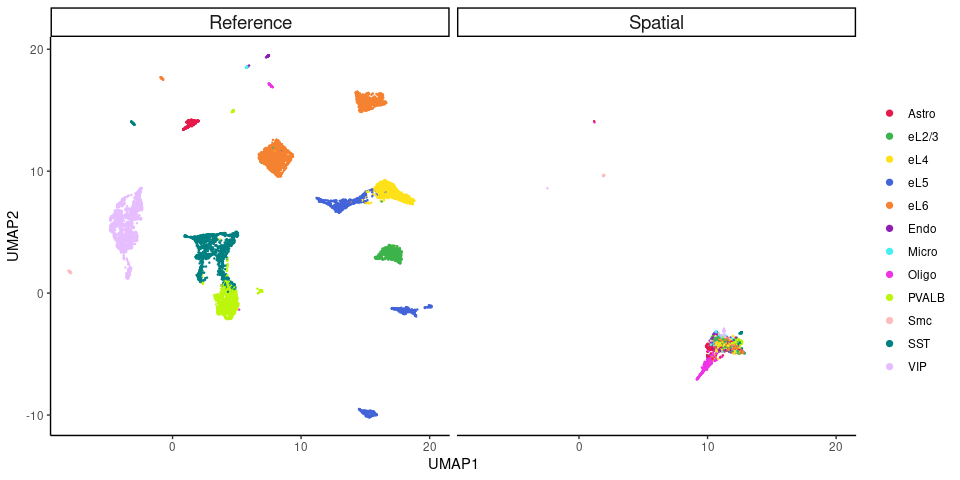

```r
ggplot(umap_before, aes(x=UMAP1, y=UMAP2, color=celltype)) +
  geom_point(shape=20, size=0.5) +
  theme_classic() +
  scale_color_manual(values = my_color) +
  facet_grid(~dataset) +
  theme(legend.title = element_blank(), strip.text = element_text(size=14)) +
  guides(color = guide_legend(override.aes = list(size = 3)))
```

## 5.2 UMAP of spatial spots and reference cells in CVAE latent space

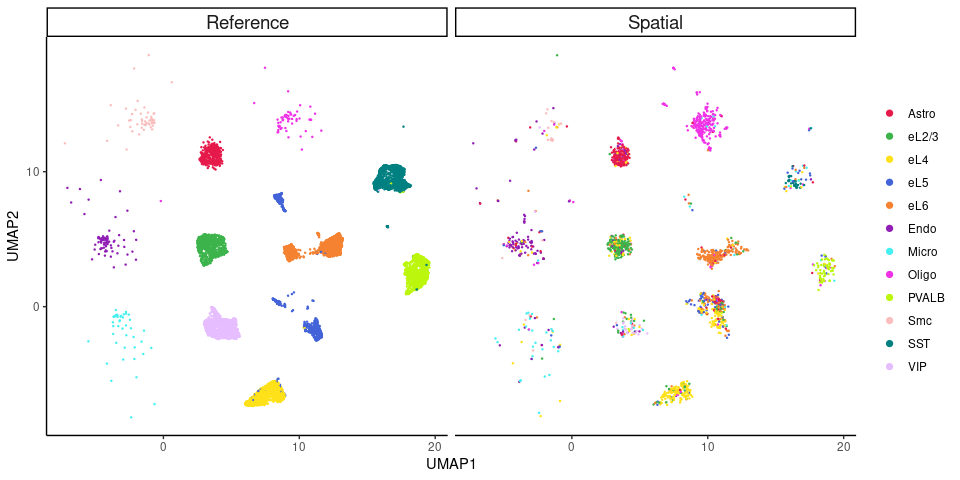

```r
ggplot(umap_latent, aes(x=UMAP1, y=UMAP2, color=celltype)) +
  geom_point(shape=20, size=0.5) +
  theme_classic() +
  scale_color_manual(values = my_color) +
  facet_grid(~dataset) +
  theme(legend.title = element_blank(), strip.text = element_text(size=14)) +
  guides(color = guide_legend(override.aes = list(size = 3)))
```

## 5.3 UMAP of spatial spots and reference cells after CVAE transformation

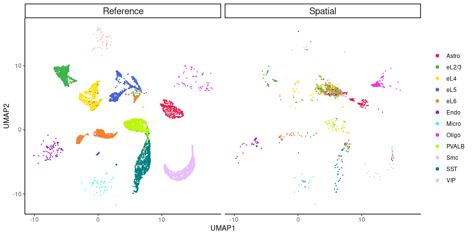

```r
ggplot(umap_after, aes(x=UMAP1, y=UMAP2, color=celltype)) +
  geom_point(shape=20, size=0.5) +
  theme_classic() +
  scale_color_manual(values = my_color) +
  facet_grid(~dataset) +
  theme(legend.title = element_blank(), strip.text = element_text(size=14)) +
  guides(color = guide_legend(override.aes = list(size = 3)))
```

## 5.4 Boxplot of performance of all methods

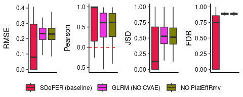

```r
plot_df = perform_raw_df

g_list = list()

for (perform_ind in c('RMSE', 'Pearson', 'JSD', 'FDR')) {
  g_list[[perform_ind]] = ggplot(plot_df, aes(x=Method, y=.data[[perform_ind]], fill=Method)) +
                            geom_boxplot(position=position_dodge(), outlier.shape=NA) +
                            scale_fill_manual(values=method_color, labels=c('SDePER'='SDePER (baseline)','GLRM'='GLRM (NO CVAE)', 'NO_PlatEffRmv'='NO PlatEffRmv')) +
                            theme_classic() +
                            theme(axis.text = element_text(color="black"),
                                  axis.ticks.x = element_blank(),
                                  axis.text.x = element_blank(),
                                  axis.title.x = element_blank(),
                                  legend.title = element_blank())

}

g_list[['Pearson']] = g_list[['Pearson']] + geom_hline(yintercept=0, color="red", linetype="dashed")

ggpubr::ggarrange(plotlist=g_list, ncol=4, nrow=1, common.legend=TRUE, legend="bottom", align = 'hv')
```

## 5.5 Addtional boxplot for FNR

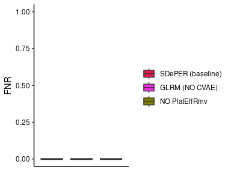

```r
ggplot(plot_df, aes(x=Method, y=FNR, fill=Method)) +
  geom_boxplot(position=position_dodge(), outlier.shape=NA) +
  scale_fill_manual(values=method_color, labels=c('SDePER'='SDePER (baseline)','GLRM'='GLRM (NO CVAE)', 'NO_PlatEffRmv'='NO PlatEffRmv')) +
  theme_classic() +
  theme(axis.text = element_text(color="black"),
        axis.ticks.x = element_blank(),
        axis.text.x = element_blank(),
        axis.title.x = element_blank(),
        legend.title = element_blank())
```